# Bechdel Test

Jo Dudding

2021-05-03

This analysis uses data from [FiveThirtyEight](https://github.com/fivethirtyeight/data/tree/master/bechdel) that was selected for [#tidytuesday](https://github.com/rfordatascience/tidytuesday/tree/master/data/2021/2021-03-09)

```r
tuesdata <- tidytuesdayR::tt_load('2021-03-09')
bechdel <- tuesdata$raw_bechdel
movies <- tuesdata$movies
```

Was going to merge in the `movies` data but the `bechdel` dataset has 8,839 rows, and `movies` has only 1,794 rows.

Let’s see what the data looks like.

```r
skim(bechdel)
```

Data summary

| Name | bechdel |
| --- | --- |
| Number of rows | 8839 |
| Number of columns | 5 |
| _______________________ |  |
| Column type frequency: |  |
| character | 2 |
| numeric | 3 |
| ________________________ |  |
| Group variables | None |

**Variable type: character**

| skim_variable | n_missing | complete_rate | min | max | empty | n_unique | whitespace |
| --- | --- | --- | --- | --- | --- | --- | --- |
| imdb_id | 4 | 1 | 5 | 9 | 0 | 8830 | 0 |
| title | 0 | 1 | 1 | 126 | 0 | 8628 | 0 |

**Variable type: numeric**

| skim_variable | n_missing | complete_rate | mean | sd | p0 | p25 | p50 | p75 | p100 | hist |
| --- | --- | --- | --- | --- | --- | --- | --- | --- | --- | --- |
| year | 0 | 1 | 1996.60 | 23.48 | 1888 | 1989.0 | 2006 | 2013.0 | 2021 | ▁▁▁▂▇ |
| id | 0 | 1 | 4695.96 | 2734.18 | 1 | 2313.5 | 4686 | 7020.5 | 9506 | ▇▇▇▇▇ |
| rating | 0 | 1 | 2.16 | 1.09 | 0 | 1.0 | 3 | 3.0 | 3 | ▂▃▁▂▇ |

Looks like the `year` is skewed. Let’s look in more detail.

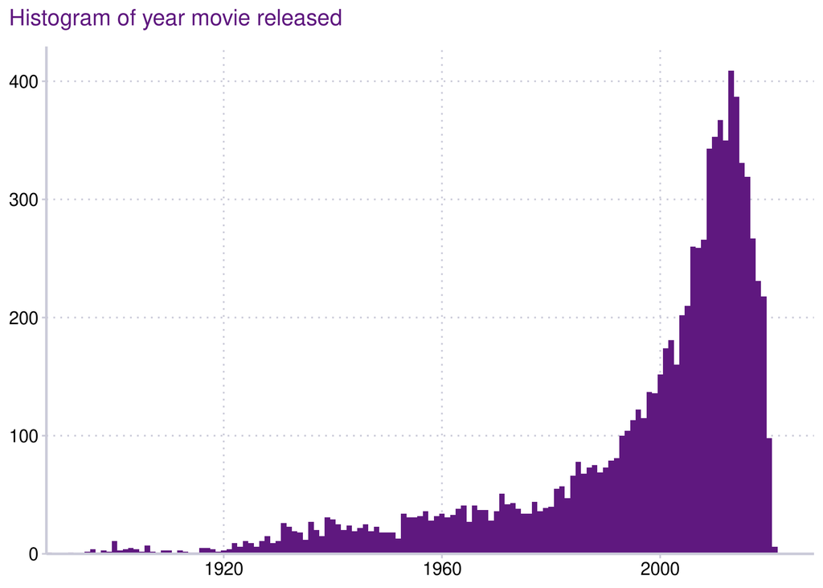

```r
bechdel %>%
ggplot(aes(year)) +
  geom_histogram(binwidth = 1, fill = add_colour) +
  scale_x_continuous(expand = expansion(mult = c(0, .05))) +
  scale_y_continuous(expand = expansion(mult = c(0, .05))) +
  labs(x = NULL, y = NULL, title = 'Histogram of year movie released')
```

Very skewed. Let’s focus on the last 50 years and remove 2021 as this will be a partial year. A variable for decade will be added.

```r
bechdel <- bechdel %>%
  filter(year <= 2020 & year > 1970) %>%
  mutate(decade = year %/% 10 * 10)
```

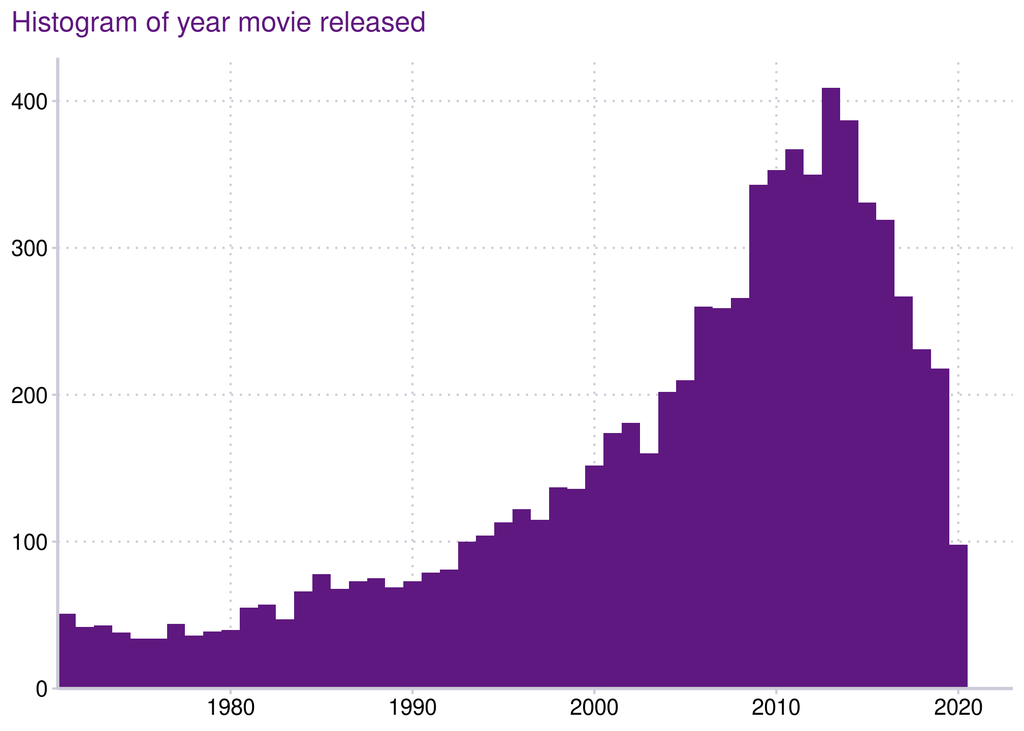

```r
bechdel %>%
ggplot(aes(year)) +
  geom_histogram(binwidth = 1, fill = add_colour) +
  scale_x_continuous(expand = expansion(mult = c(0, .05))) +
  scale_y_continuous(expand = expansion(mult = c(0, .05))) +
  labs(x = NULL, y = NULL, title = 'Histogram of year movie released')
```

Now let’s have a look at the Bechdel score. First we need to make the variable more meaningful.

```r
bechdel <- bechdel %>%
  mutate(
    bechdel = fct_reorder(case_when(
      rating == 0 ~ "Fail - two named women",
      rating == 1 ~ "Fail - talk to each other",
      rating == 2 ~ "Fail - conversation about men",
      rating == 3 ~ "Pass"
    ), rating)
  )
```

Then let’s make a pie chart of this.

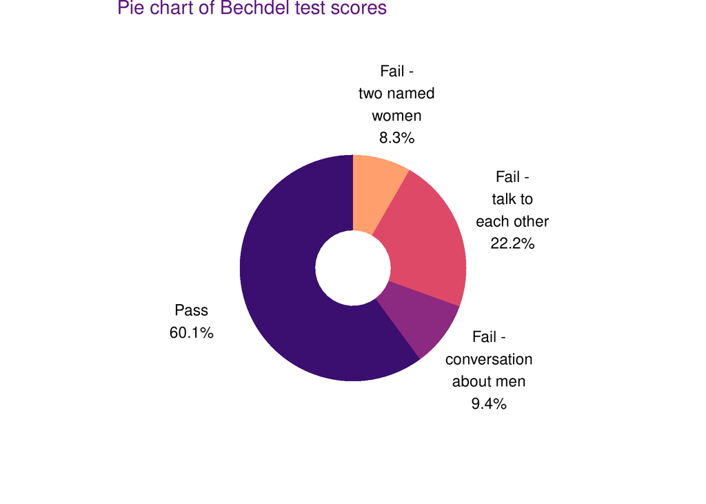

```r
bechdel %>%
  count(bechdel) %>%
  mutate(
    pct = n / sum(n),
    label = paste0(
      str_wrap(bechdel, 10),
      '\n',
      percent(pct)
    )
  ) %>%
ggplot(aes(1, pct, label = label, fill = fct_rev(bechdel))) +
  geom_col(width = 2) +
  geom_text(aes(x = 3.5), position = position_stack(vjust = 0.5)) +
  scale_x_continuous(limits = c(-1, 4)) +
  scale_fill_manual(values = viridisLite::magma(6)[2:5]) +
  coord_polar(theta = 'y') +
  theme_void() +
  guides(fill = 'none') +
  labs(title = 'Pie chart of Bechdel test scores') +
  theme(
    # align title and caption to the plot not the panel
    plot.title.position = 'plot',
    plot.caption.position = 'plot',
    # change the title and caption to markdown and move them further from the plot
    plot.title = element_markdown(
      hjust = 0,
      margin = margin(c(0, 0, 10, 0)),
      colour = add_colour,
        size = rel(1.25)
    ),
    plot.subtitle = element_markdown(
      hjust = 0,
      margin = margin(c(0, 0, 15, 0))
    ),
    plot.caption = element_markdown(
      hjust = 1,
      margin = margin(c(10, 0, 0, 0))
    )
  )
```

Let’s see how this has been changing over time.

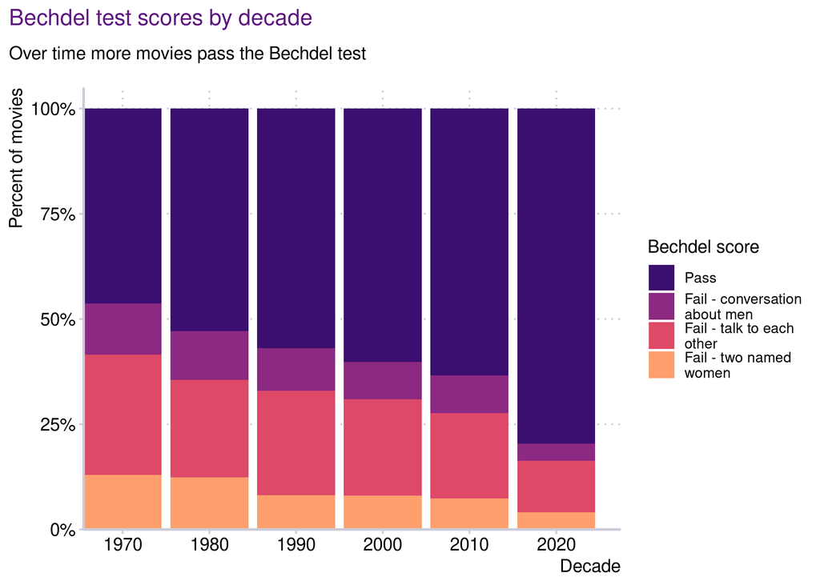

```r
bechdel %>%
  count(decade, bechdel) %>%
  group_by(decade) %>%
  mutate(
    pct = n / sum(n),
    label = percent(pct)
  ) %>%
  ungroup() %>%
ggplot(aes(decade, pct, label = label, fill = fct_rev(bechdel))) +
  geom_col() +
  #geom_text(aes(x = 3.5), position = position_stack(vjust = 0.5)) +
  scale_x_continuous(expand = expansion(mult = c(0, .05))) +
  scale_y_continuous(
    expand = expansion(mult = c(0, .05)),
    label = percent_format()
  ) +
  scale_fill_manual(
    values = viridisLite::magma(6)[2:5],
    label = label_wrap(20)
  ) +
  labs(
    x = 'Decade',
    y = 'Percent of movies',
    fill = 'Bechdel score',
    title = 'Bechdel test scores by decade',
    subtitle = 'Over time more movies pass the Bechdel test'
  )
```

Let’s see the names of some of the movies in 2020 that have failed the Bechdel test.

- Summerland ( Fail - talk to each other )
- Scare Me ( Fail - talk to each other )
- The Stunt Double ( Fail - talk to each other )
- Honey Boy ( Fail - two named women )
- The Rhythm Section ( Fail - conversation about men )
- Bad Boys For Life ( Fail - conversation about men )
- The Witches ( Fail - conversation about men )
- Tenet ( Fail - talk to each other )
- Tout simplement noir ( Fail - talk to each other )
- Druk ( Fail - talk to each other )
- Jiu Jitsu ( Fail - talk to each other )
- The Trial of the Chicago 7 ( Fail - talk to each other )
- Over the Moon ( Fail - talk to each other )
- Mank ( Fail - talk to each other )
- Sputnik ( Fail - two named women )
- Santana ( Fail - talk to each other )
- Living Aims ( Fail - conversation about men )
- The last days of american crime ( Fail - two named women )
- Greyhound ( Fail - two named women )
- Breach ( Fail - talk to each other )